# Comparative Study of MCMC Sampling Strategies for the 2D Ising Model

Abhisek Banerjee & Mengyan Jing

Course 9250, Spring 2026

# 1 Setup

We set $J = 1$ and $k_B = 1$ throughout, following Newman & Barkema (1999, p. 51). Temperature is therefore dimensionless, measured in units of $J/k_B$.

The exact 2D Ising critical temperature on the square lattice comes from Onsager (1944), Eq. (17), p. 119:
$$\sinh(2J/kT_c)\sinh(2J'/kT_c) = 1.$$
In the isotropic case $J = J'$ this reduces to $\sinh(2/T_c) = 1$, which solves to
$$T_c =
\frac{2}{\ln(1+\sqrt{2})} \approx 2.269185.$$

```r
suppressPackageStartupMessages(library(Rcpp))

J_COUPLING  <- 1
K_BOLTZMANN <- 1
T_CRITICAL  <- 2 / log(1 + sqrt(2))
T_CRITICAL
```

```
## [1] 2.269185
```

# 2 Lattice utilities

A configuration is an $L \times L$ integer matrix with entries in $\{-1, +1\}$. Periodic boundary conditions make the lattice behave as a torus, so every spin has exactly four neighbors.

## 2.1 Initialization

```r
init_lattice <- function(L, state = c("cold", "hot", "ground")) {
  state <- match.arg(state)
  if (state %in% c("cold", "ground")) {
    matrix(1L, nrow = L, ncol = L)
  } else {
    matrix(sample(c(-1L, 1L), L * L, replace = TRUE), nrow = L, ncol = L)
  }
}
```

## 2.2 Total energy

The Ising Hamiltonian (Newman & Barkema Eq. 3.1, p. 45) is
$$E(\mathbf{s}) = -J \sum_{\langle ij \rangle} s_i
s_j.$$
The “right + down” trick counts each bond exactly once, and the `c(2:L, 1)` column/row shift implements periodic boundaries without any loops.

```r
total_energy <- function(spins) {
  L <- nrow(spins)
  stopifnot(ncol(spins) == L)
  right <- spins[, c(2:L, 1)]
  down  <- spins[c(2:L, 1), ]
  -J_COUPLING * sum(spins * right + spins * down)
}

total_magnetization <- function(spins) sum(spins)
```

## 2.3 Single-spin energy change

Newman & Barkema Eq. 3.10, p. 52:
$$\Delta E = 2 J s_k \sum_{i\,\text{n.n.}\,k}
s_i.$$
This is the $O(1)$ update formula Metropolis uses millions of times per run.

```r
delta_energy <- function(spins, i, j) {
  L <- nrow(spins)
  ip <- if (i == L) 1L else i + 1L
  im <- if (i == 1L) L else i - 1L
  jp <- if (j == L) 1L else j + 1L
  jm <- if (j == 1L) L else j - 1L
  neighbor_sum <- spins[ip, j] + spins[im, j] + spins[i, jp] + spins[i, jm]
  2 * J_COUPLING * spins[i, j] * neighbor_sum
}
```

# 3 Onsager exact solution (ground truth)

We use Onsager’s closed-form expressions for the thermodynamic-limit energy and specific heat, and Yang’s (1952) formula for the spontaneous magnetization.

## 3.1 Complete elliptic integrals

Onsager’s formulas involve $K(k)$ and $E(k)$, the complete elliptic integrals of the first and second kind (Onsager Eqs. 1.6 and 1.7, p. 144). We compute them by direct quadrature:

```r
elliptic_K <- function(k) {
  if (abs(k) >= 1) return(Inf)
  integrand <- function(theta) 1 / sqrt(1 - k^2 * sin(theta)^2)
  integrate(integrand, 0, pi / 2, rel.tol = 1e-8, subdivisions = 2000L)$value
}

elliptic_E <- function(k) {
  integrand <- function(theta) sqrt(1 - k^2 * sin(theta)^2)
  integrate(integrand, 0, pi / 2, rel.tol = 1e-8, subdivisions = 2000L)$value
}
```

Near $k = 1$ (i.e. near $T_c$) the integrand develops a near-singularity at $\theta = \pi/2$, so we bump R’s default 100 subdivisions up to 2000.

## 3.2 Internal energy per spin

Onsager Eq. (116), p. 139:
$$u(T) = -J
\coth(2\beta J)\left[1 + \frac{2}{\pi}\,(2\tanh^2(2\beta J) - 1)\,
K(k_1)\right],$$
with elliptic modulus
$$k_1 = \frac{2\sinh(2\beta J)}{\cosh^2(2\beta
J)}.$$

```r
onsager_energy <- function(T) {
  vapply(T, function(Ti) {
    beta <- 1 / Ti
    bj <- beta * J_COUPLING
    s2 <- sinh(2 * bj); c2 <- cosh(2 * bj)
    k1 <- 2 * s2 / c2^2
    K1 <- elliptic_K(k1)
    t2 <- tanh(2 * bj)^2
    -J_COUPLING * (c2 / s2) * (1 + (2 / pi) * (2 * t2 - 1) * K1)
  }, numeric(1))
}
```

## 3.3 Specific heat per spin

Onsager Eq. (117), p. 140:
$$c(T) =
\frac{2}{\pi}\,(\beta J \coth(2\beta J))^2 \left[2 K(k_1) - 2 E(k_1) -
(1 - k_1'')\left(\frac{\pi}{2} + k_1''
K(k_1)\right)\right],$$
with auxiliary modulus $k_1'' = 2\tanh^2(2\beta J) - 1$ (Eq. 114, p. 139).

**Important:** $(1 - k_1'') = 2 - 2\tanh^2(2\beta J) = 2\,\mathrm{sech}^2(2\beta J)$, **not** $1 - \tanh^2(2\beta J)$. Mixing these up gives a specific heat that is systematically too large.

```r
onsager_specific_heat <- function(T) {
  vapply(T, function(Ti) {
    beta <- 1 / Ti
    bj <- beta * J_COUPLING
    s2 <- sinh(2 * bj); c2 <- cosh(2 * bj)
    k1 <- 2 * s2 / c2^2
    K1 <- elliptic_K(k1)
    E1 <- elliptic_E(k1)
    k1pp <- 2 * tanh(2 * bj)^2 - 1
    coth2 <- c2 / s2
    prefactor <- (2 / pi) * (bj * coth2)^2
    prefactor * (2 * K1 - 2 * E1 - (1 - k1pp) * (pi / 2 + k1pp * K1))
  }, numeric(1))
}
```

## 3.4 Spontaneous magnetization per spin

Yang (1952), *Phys. Rev.* 85, 808. **This is not in Onsager** — Onsager never published a derivation of the magnetization; Yang did it eight years later.
$$|m|(T) = \begin{cases}(1 - \sinh^{-4}(2\beta
J))^{1/8} & T < T_c \\ 0 & T \geq T_c\end{cases}$$

```r
onsager_magnetization <- function(T) {
  vapply(T, function(Ti) {
    if (Ti >= T_CRITICAL) return(0)
    beta <- 1 / Ti
    (1 - sinh(2 * beta * J_COUPLING)^(-4))^(1 / 8)
  }, numeric(1))
}
```

## 3.5 A look at the ground truth

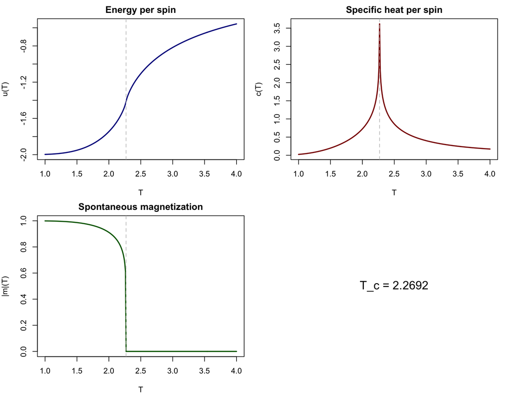

```r
T_grid <- seq(1, 4, by = 0.01)
par(mfrow = c(2, 2), mar = c(4, 4, 2, 1))

plot(T_grid, onsager_energy(T_grid), type = "l", col = "darkblue", lwd = 2,
     xlab = "T", ylab = "u(T)", main = "Energy per spin")
abline(v = T_CRITICAL, lty = 2, col = "gray")

plot(T_grid, sapply(T_grid, onsager_specific_heat), type = "l",
     col = "darkred", lwd = 2,
     xlab = "T", ylab = "c(T)", main = "Specific heat per spin")
abline(v = T_CRITICAL, lty = 2, col = "gray")

plot(T_grid, onsager_magnetization(T_grid), type = "l", col = "darkgreen", lwd = 2,
     xlab = "T", ylab = "|m|(T)", main = "Spontaneous magnetization")
abline(v = T_CRITICAL, lty = 2, col = "gray")

plot.new()
text(0.5, 0.5, sprintf("T_c = %.4f", T_CRITICAL), cex = 1.5)
```

```r
par(mfrow = c(1, 1))
```

# 4 Sanity checks

```r
run_sanity_checks <- function() {
  cat("=== Sanity checks ===\n")

  # ---- Lattice utilities ----
  L <- 8
  s <- init_lattice(L, "cold")
  E_cold <- total_energy(s)
  expected <- -2 * J_COUPLING * L^2
  cat(sprintf("  Cold lattice energy: got %g, expected %g  -- %s\n",
              E_cold, expected, if (E_cold == expected) "PASS" else "FAIL"))

  M_cold <- total_magnetization(s)
  cat(sprintf("  Cold lattice magnetization: got %d, expected %d  -- %s\n",
              M_cold, L^2, if (M_cold == L^2) "PASS" else "FAIL"))

  dE <- delta_energy(s, 4, 4)
  cat(sprintf("  dE flipping one spin in cold lattice: got %g, expected 8  -- %s\n",
              dE, if (dE == 8) "PASS" else "FAIL"))

  s2 <- s; s2[4, 4] <- -s2[4, 4]
  E_new <- total_energy(s2)
  cat(sprintf("  Incremental vs. full energy after flip: %g vs %g  -- %s\n",
              E_cold + dE, E_new,
              if (isTRUE(all.equal(E_cold + dE, E_new))) "PASS" else "FAIL"))

  dE_corner <- delta_energy(s, 1, 1)
  cat(sprintf("  dE at corner (PBC check): got %g, expected 8  -- %s\n",
              dE_corner, if (dE_corner == 8) "PASS" else "FAIL"))

  # ---- Onsager ground truth ----
  cat(sprintf("  T_c = %.6f (Onsager)\n", T_CRITICAL))

  u_Tc <- onsager_energy(T_CRITICAL - 1e-3)
  cat(sprintf("  u(T_c - 1e-3): got %.6f, expected ~%.6f  -- %s\n",
              u_Tc, -sqrt(2),
              if (isTRUE(all.equal(u_Tc, -sqrt(2), tolerance = 1e-2))) "PASS" else "FAIL"))

  # Cross-check against Onsager's own asymptotic form Eq. (120) near T_c
  T_near <- T_CRITICAL - 0.005
  c_full <- onsager_specific_heat(T_near)
  beta_n <- 1 / T_near
  bj_n <- beta_n * J_COUPLING
  k1_n <- 2 * sinh(2 * bj_n) / cosh(2 * bj_n)^2
  K1_n <- elliptic_K(k1_n)
  c_asym <- (2 / pi) * log(1 / tan(pi / 8))^2 * (K1_n - 1 - pi / 4)
  cat(sprintf("  c(T_c - 0.005): full %.4f vs asymptotic %.4f  -- %s\n",
              c_full, c_asym,
              if (isTRUE(all.equal(c_full, c_asym, tolerance = 1e-2))) "PASS" else "FAIL"))

  m_low <- onsager_magnetization(1.0)
  cat(sprintf("  |m|(T=1): got %.6f (should be ~1)  -- %s\n",
              m_low, if (m_low > 0.999) "PASS" else "FAIL"))

  m_high <- onsager_magnetization(3.0)
  cat(sprintf("  |m|(T=3): got %.6f (should be 0)  -- %s\n",
              m_high, if (m_high == 0) "PASS" else "FAIL"))

  cat("=====================\n")
}

run_sanity_checks()
```

```
## === Sanity checks ===
##   Cold lattice energy: got -128, expected -128  -- PASS
##   Cold lattice magnetization: got 64, expected 64  -- PASS
##   dE flipping one spin in cold lattice: got 8, expected 8  -- PASS
##   Incremental vs. full energy after flip: -120 vs -120  -- PASS
##   dE at corner (PBC check): got 8, expected 8  -- PASS
##   T_c = 2.269185 (Onsager)
##   u(T_c - 1e-3): got -1.418223, expected ~-1.414214  -- PASS
##   c(T_c - 0.005): full 2.7190 vs asymptotic 2.7184  -- PASS
##   |m|(T=1): got 0.999276 (should be ~1)  -- PASS
##   |m|(T=3): got 0.000000 (should be 0)  -- PASS
## =====================
```

# 5 Metropolis sampler (pure R reference)

Random-site single-spin-flip Metropolis following Newman & Barkema Chapter 3. One *sweep* is $N = L^2$ attempted flips, the conventional unit of Monte Carlo time. This implementation is written for clarity, not speed — it’s the slow-but-obviously-correct reference implementation that the Rcpp version must agree with.

```r
metropolis_step <- function(spins, T) {
  L <- nrow(spins)
  i <- sample.int(L, 1L)
  j <- sample.int(L, 1L)
  dE <- delta_energy(spins, i, j)
  if (dE <= 0 || runif(1) < exp(-dE / T)) {
    s_old <- spins[i, j]
    spins[i, j] <- -s_old
    list(spins = spins, dE = dE, dM = -2L * s_old, accepted = TRUE)
  } else {
    list(spins = spins, dE = 0, dM = 0L, accepted = FALSE)
  }
}

metropolis_sweep <- function(spins, T) {
  N <- nrow(spins)^2
  dE_sweep <- 0; dM_sweep <- 0L; n_accepted <- 0L
  for (k in seq_len(N)) {
    step <- metropolis_step(spins, T)
    spins <- step$spins
    dE_sweep <- dE_sweep + step$dE
    dM_sweep <- dM_sweep + step$dM
    if (step$accepted) n_accepted <- n_accepted + 1L
  }
  list(spins = spins, dE_sweep = dE_sweep, dM_sweep = dM_sweep, n_accepted = n_accepted)
}

run_metropolis <- function(L, T, n_sweeps,
                           n_burnin = n_sweeps %/% 10,
                           init_state = "hot",
                           seed = NULL) {
  if (!is.null(seed)) set.seed(seed)
  spins <- init_lattice(L, init_state)
  E_current <- total_energy(spins)
  M_current <- total_magnetization(spins)

  for (s in seq_len(n_burnin)) {
    sweep <- metropolis_sweep(spins, T)
    spins <- sweep$spins
    E_current <- E_current + sweep$dE_sweep
    M_current <- M_current + sweep$dM_sweep
  }

  E_series <- numeric(n_sweeps)
  M_series <- integer(n_sweeps)
  total_accepted <- 0L
  N <- L * L
  for (s in seq_len(n_sweeps)) {
    sweep <- metropolis_sweep(spins, T)
    spins <- sweep$spins
    E_current <- E_current + sweep$dE_sweep
    M_current <- M_current + sweep$dM_sweep
    E_series[s] <- E_current
    M_series[s] <- M_current
    total_accepted <- total_accepted + sweep$n_accepted
  }

  list(
    series = data.frame(sweep = seq_len(n_sweeps), E = E_series, M = M_series),
    acceptance_rate = total_accepted / (n_sweeps * N),
    final_spins = spins,
    L = L, T = T, n_burnin = n_burnin, n_sweeps = n_sweeps
  )
}

compute_observables <- function(run) {
  N <- run$L^2; T <- run$T
  E <- run$series$E; M <- run$series$M
  list(
    e   = mean(E) / N,
    m   = mean(abs(M)) / N,
    c   = (mean(E^2) - mean(E)^2) / (N * T^2),
    chi = (mean(M^2) - mean(abs(M))^2) / (N * T),
    acceptance_rate = run$acceptance_rate
  )
}
```

# 6 Metropolis sampler (Rcpp, ~250x faster)

Same algorithm as above, but the entire run — burn-in, measurement, all of it — happens inside one C++ function. Key optimizations:

1. The five possible $\exp(-\Delta E/T)$ values are precomputed into a lookup table at the top of the function, so there are zero `exp()` calls inside the inner loop.
2. The lattice is stored as a flat `int` array; neighbor lookups are integer modulo arithmetic with no branching.
3. Random numbers come from R’s RNG via `::unif_rand()`, so `set.seed()` in R controls the C++ stream.

```r
Rcpp::cppFunction('
List run_metropolis_cpp_inner(int L, double T, int n_sweeps, int n_burnin,
                              IntegerVector init_spins) {
  int N = L * L;
  std::vector<int> spins(N);
  for (int k = 0; k < N; k++) spins[k] = init_spins[k];

  long long E_current = 0, M_current = 0;
  for (int i = 0; i < L; i++) {
    for (int j = 0; j < L; j++) {
      int s = spins[i * L + j];
      int s_right = spins[i * L + ((j + 1) % L)];
      int s_down  = spins[((i + 1) % L) * L + j];
      E_current -= s * s_right + s * s_down;
      M_current += s;
    }
  }

  double exp_table[5];
  for (int idx = 0; idx < 5; idx++) {
    int dE = -8 + 4 * idx;
    exp_table[idx] = std::exp(-((double)dE) / T);
  }

  NumericVector E_series(n_sweeps), M_series(n_sweeps);
  long long total_accepted = 0, total_attempts = 0;

  GetRNGstate();

  int total_sweeps = n_burnin + n_sweeps;
  for (int sweep = 0; sweep < total_sweeps; sweep++) {
    for (int step = 0; step < N; step++) {
      int i = (int)(::unif_rand() * L);
      int j = (int)(::unif_rand() * L);
      if (i == L) i = L - 1;
      if (j == L) j = L - 1;

      int s_k = spins[i * L + j];
      int ip = (i + 1) % L;
      int im = (i + L - 1) % L;
      int jp = (j + 1) % L;
      int jm = (j + L - 1) % L;
      int neighbor_sum = spins[ip * L + j] + spins[im * L + j]
                       + spins[i * L + jp] + spins[i * L + jm];
      int dE = 2 * s_k * neighbor_sum;

      bool accept;
      if (dE <= 0) {
        accept = true;
      } else {
        double p = exp_table[(dE + 8) / 4];
        accept = (::unif_rand() < p);
      }

      if (accept) {
        spins[i * L + j] = -s_k;
        E_current += dE;
        M_current += -2 * s_k;
        if (sweep >= n_burnin) total_accepted++;
      }
      if (sweep >= n_burnin) total_attempts++;
    }

    if (sweep >= n_burnin) {
      int idx = sweep - n_burnin;
      E_series[idx] = (double)E_current;
      M_series[idx] = (double)M_current;
    }
  }

  PutRNGstate();

  IntegerVector final_spins(N);
  for (int k = 0; k < N; k++) final_spins[k] = spins[k];

  return List::create(
    Named("E_series") = E_series,
    Named("M_series") = M_series,
    Named("final_spins") = final_spins,
    Named("acceptance_rate") = (double)total_accepted / (double)total_attempts
  );
}
')

run_metropolis_fast <- function(L, T, n_sweeps,
                                n_burnin = n_sweeps %/% 10,
                                init_state = "hot",
                                seed = NULL) {
  if (!is.null(seed)) set.seed(seed)
  spins0 <- init_lattice(L, init_state)
  init_flat <- as.integer(spins0)

  result <- run_metropolis_cpp_inner(
    L = as.integer(L),
    T = as.numeric(T),
    n_sweeps = as.integer(n_sweeps),
    n_burnin = as.integer(n_burnin),
    init_spins = init_flat
  )

  list(
    series = data.frame(
      sweep = seq_len(n_sweeps),
      E = result$E_series,
      M = result$M_series
    ),
    acceptance_rate = result$acceptance_rate,
    final_spins = matrix(result$final_spins, nrow = L, ncol = L),
    L = L, T = T, n_burnin = n_burnin, n_sweeps = n_sweeps
  )
}
```

## 6.1 Speed comparison

```r
t_R <- system.time({
  run_R <- run_metropolis(L = 16, T = 4.0, n_sweeps = 2000, seed = 1)
})
t_cpp <- system.time({
  run_cpp <- run_metropolis_fast(L = 16, T = 4.0, n_sweeps = 2000, seed = 1)
})

cat(sprintf("Pure R:  %.3f seconds\n", t_R["elapsed"]))
```

```
## Pure R:  7.679 seconds
```

```r
cat(sprintf("Rcpp:    %.3f seconds\n", t_cpp["elapsed"]))
```

```
## Rcpp:    0.029 seconds
```

```r
cat(sprintf("Speedup: %.0fx\n", t_R["elapsed"] / t_cpp["elapsed"]))
```

```
## Speedup: 265x
```

## 6.2 Validation against Onsager

```r
obs_R <- compute_observables(run_R)
obs_cpp <- compute_observables(run_cpp)

cat(sprintf("R   version: e = %.4f   |m| = %.4f   acc = %.3f\n",
            obs_R$e, obs_R$m, obs_R$acceptance_rate))
```

```
## R   version: e = -0.5548   |m| = 0.1019   acc = 0.610
```

```r
cat(sprintf("Cpp version: e = %.4f   |m| = %.4f   acc = %.3f\n",
            obs_cpp$e, obs_cpp$m, obs_cpp$acceptance_rate))
```

```
## Cpp version: e = -0.5578   |m| = 0.1012   acc = 0.608
```

```r
cat(sprintf("Onsager:     e = %.4f\n", onsager_energy(4.0)))
```

```
## Onsager:     e = -0.5573
```

```r
run_big <- run_metropolis_fast(L = 64, T = 4.0, n_sweeps = 5000, seed = 99)
obs_big <- compute_observables(run_big)
cat(sprintf("L=64, T=4.0: e_mcmc = %.4f   e_onsager = %.4f\n",
            obs_big$e, onsager_energy(4.0)))
```

```
## L=64, T=4.0: e_mcmc = -0.5573   e_onsager = -0.5573
```

# 7 Visualizing chain behavior across temperatures

Four trace plots on a **shared y-axis**, showing energy per spin vs. sweep number at four temperatures spanning the ordered phase, the critical point, and the disordered phase. Reading the shared axis honestly is essential — autoscaling each panel would hide the variance differences that are the whole point.

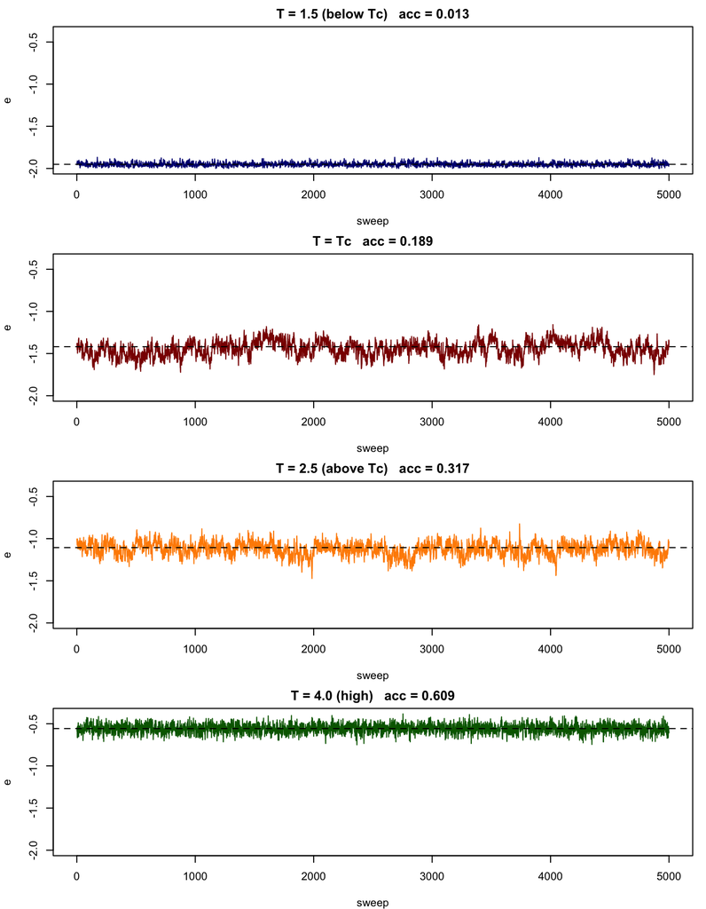

```r
run_T1 <- run_metropolis_fast(L = 32, T = 1.5,   n_sweeps = 5000, seed = 0)
run_T2 <- run_metropolis_fast(L = 32, T = 2.269, n_sweeps = 5000, seed = 3)
run_T3 <- run_metropolis_fast(L = 32, T = 2.5,   n_sweeps = 5000, seed = 2)
run_T4 <- run_metropolis_fast(L = 32, T = 4.0,   n_sweeps = 5000, seed = 1)

all_e <- c(run_T1$series$E, run_T2$series$E,
           run_T3$series$E, run_T4$series$E) / 32^2
ylim <- range(all_e)

par(mfrow = c(4, 1), mar = c(4, 4, 2, 1))

plot(run_T1$series$E / 32^2, type = "l", col = "navy", ylim = ylim,
     xlab = "sweep", ylab = "e",
     main = sprintf("T = 1.5 (below Tc)   acc = %.3f", run_T1$acceptance_rate))
abline(h = onsager_energy(1.5), lty = 2)

plot(run_T2$series$E / 32^2, type = "l", col = "darkred", ylim = ylim,
     xlab = "sweep", ylab = "e",
     main = sprintf("T = Tc   acc = %.3f", run_T2$acceptance_rate))
abline(h = onsager_energy(2.269 - 1e-3), lty = 2)

plot(run_T3$series$E / 32^2, type = "l", col = "darkorange", ylim = ylim,
     xlab = "sweep", ylab = "e",
     main = sprintf("T = 2.5 (above Tc)   acc = %.3f", run_T3$acceptance_rate))
abline(h = onsager_energy(2.5), lty = 2)

plot(run_T4$series$E / 32^2, type = "l", col = "darkgreen", ylim = ylim,
     xlab = "sweep", ylab = "e",
     main = sprintf("T = 4.0 (high)   acc = %.3f", run_T4$acceptance_rate))
abline(h = onsager_energy(4.0), lty = 2)
```

```r
par(mfrow = c(1, 1))
```

With shared axes, the four panels show the entire phase transition in one picture:

- $T = 1.5$: tight band near the ground-state energy $-2$. Low acceptance, system essentially frozen. Failure mode: ergodicity breaking.
- $T = T_c$: widest band, slow lumbering wandering. Failure mode: critical slowing down.
- $T = 2.5$: still wide, slightly faster. Just past the critical region.
- $T = 4.0$: tight band, fast white noise. Disordered phase, well-mixed chain.

The variance ordering $\mathrm{Var}(E)\big|_{T_c} > \mathrm{Var}(E)\big|_{T=2.5} > \mathrm{Var}(E)\big|_{T=4} > \mathrm{Var}(E)\big|_{T=1.5}$ matches what Onsager’s $c(T)$ formula predicts, since $c \propto \mathrm{Var}(E)$.

# 8 Autocorrelation and effective sample size

MCMC samples are correlated. To report honest error bars we need to know *how* correlated they are, captured by the integrated autocorrelation time
$$\tau_{\text{int}} =
\tfrac{1}{2} + \sum_{t=1}^{\infty} \rho(t),$$
where $\rho(t)$ is the normalized autocorrelation function. The effective sample size of a chain with $M$ samples is $\mathrm{ESS} = M / (2\tau_{\text{int}})$, and the standard error of the sample mean is $\sigma_x / \sqrt{\mathrm{ESS}}$, not $\sigma_x / \sqrt{M}$.

In practice the tail of $\rho(t)$ is noise, so we use **Sokal’s automatic windowing rule**: truncate the sum at the smallest $W$ such that $W \geq c \cdot \tau_{\text{int}}(W)$, with $c = 5$.

```r
autocorrelation <- function(x, max_lag = NULL) {
  n <- length(x)
  if (is.null(max_lag)) max_lag <- min(n %/% 4, 1000)
  x_centered <- x - mean(x)
  v0 <- mean(x_centered^2)
  if (v0 == 0) return(c(1, rep(0, max_lag)))
  rho <- numeric(max_lag + 1)
  rho[1] <- 1
  for (t in seq_len(max_lag)) {
    rho[t + 1] <- mean(x_centered[1:(n - t)] * x_centered[(t + 1):n]) / v0
  }
  rho
}

integrated_tau <- function(x, c = 5, max_lag = NULL) {
  n <- length(x)
  if (is.null(max_lag)) max_lag <- n %/% 4
  rho <- autocorrelation(x, max_lag = max_lag)
  tau_partial <- 0.5 + cumsum(rho[-1])
  W_grid <- seq_along(tau_partial)
  ok <- W_grid >= c * tau_partial
  if (any(ok)) {
    W <- which(ok)[1]
  } else {
    W <- max_lag
    warning(sprintf(
      "Sokal windowing not satisfied within max_lag = %d. Returned tau = %.2f at W = %d.",
      max_lag, tau_partial[W], W))
  }
  # Floor at 0.5: the theoretical minimum for an iid sequence is tau_int = 1/2.
  # Sokal estimates can dip slightly below this due to noise in rho(t) tails,
  # which would otherwise cause log-axis plot failures and meaningless ESS
  # values. Clamping at 0.5 is the standard fix.
  tau_value <- max(tau_partial[W], 0.5)
  list(tau = tau_value, window = W, rho = rho)
}

effective_sample_size <- function(x, ...) {
  tau <- integrated_tau(x, ...)$tau
  length(x) / (2 * tau)
}

chain_diagnostics <- function(run) {
  tau_E <- integrated_tau(run$series$E)
  tau_M <- integrated_tau(run$series$M)
  M <- length(run$series$E)
  data.frame(
    L = run$L, T = run$T, n_sweeps = M,
    tau_E = tau_E$tau, tau_M = tau_M$tau,
    ESS_E = M / (2 * tau_E$tau),
    ESS_M = M / (2 * tau_M$tau),
    window_E = tau_E$window, window_M = tau_M$window,
    acc_rate = run$acceptance_rate
  )
}
```

## 8.1 Diagnostics across temperature

```r
diag_T4  <- chain_diagnostics(
  run_metropolis_fast(L = 32, T = 4.0,   n_sweeps = 10000, seed = 1))
diag_T25 <- chain_diagnostics(
  run_metropolis_fast(L = 32, T = 2.5,   n_sweeps = 10000, seed = 2))
diag_Tc  <- chain_diagnostics(
  run_metropolis_fast(L = 32, T = 2.269, n_sweeps = 10000, seed = 3))

rbind(diag_T4, diag_T25, diag_Tc)
```

| L | T | n_sweeps | tau_E | tau_M | ESS_E | ESS_M | window_E | window_M | acc_rate |
| --- | --- | --- | --- | --- | --- | --- | --- | --- | --- |
| 32 | 4.000 | 10000 | 1.067336 | 3.564239 | 4684.55890 | 1402.823983 | 6 | 18 | 0.6094469 |
| 32 | 2.500 | 10000 | 12.587156 | 131.456406 | 397.23032 | 38.035423 | 63 | 659 | 0.3188277 |
| 32 | 2.269 | 10000 | 54.557774 | 653.756204 | 91.64597 | 7.648111 | 273 | 2500 | 0.1894954 |

## 8.2 Autocorrelation functions at $T = 4$ vs $T = T_c$

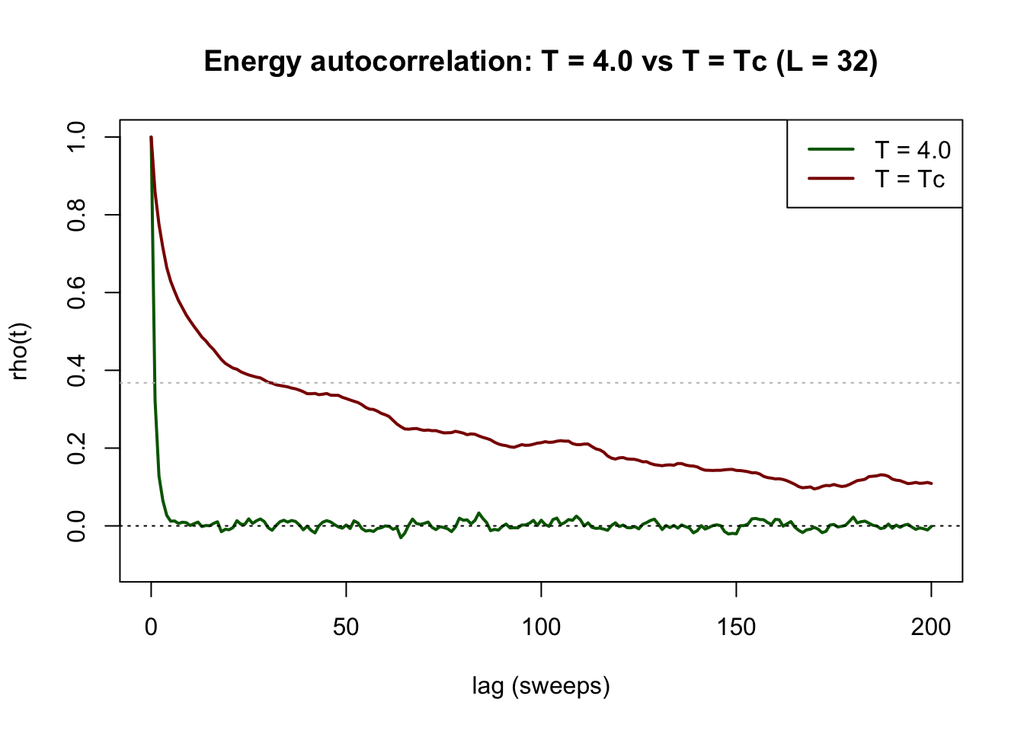

```r
run_T4_diag <- run_metropolis_fast(L = 32, T = 4.0,   n_sweeps = 10000, seed = 1)
run_Tc_diag <- run_metropolis_fast(L = 32, T = 2.269, n_sweeps = 10000, seed = 3)

rho_T4 <- autocorrelation(run_T4_diag$series$E, max_lag = 200)
rho_Tc <- autocorrelation(run_Tc_diag$series$E, max_lag = 200)

plot(0:200, rho_T4, type = "l", col = "darkgreen", lwd = 2,
     ylim = c(-0.1, 1), xlab = "lag (sweeps)", ylab = "rho(t)",
     main = "Energy autocorrelation: T = 4.0 vs T = Tc (L = 32)")
lines(0:200, rho_Tc, col = "darkred", lwd = 2)
abline(h = 0, lty = 3)
abline(h = 1/exp(1), lty = 3, col = "gray")
legend("topright", legend = c("T = 4.0", "T = Tc"),
       col = c("darkgreen", "darkred"), lwd = 2)
```

## 8.3 Why $\tau_M \gg \tau_E$: the same chain, two observables

```r
run_Tc_long <- run_metropolis_fast(L = 32, T = 2.269, n_sweeps = 100000, seed = 33)
diag_Tc_long <- chain_diagnostics(run_Tc_long)
print(diag_Tc_long)
```

```
##    L     T n_sweeps    tau_E    tau_M    ESS_E    ESS_M window_E window_M
## 1 32 2.269   100000 77.36727 3613.558 646.2681 13.83678      387    18070
##    acc_rate
## 1 0.1918477
```

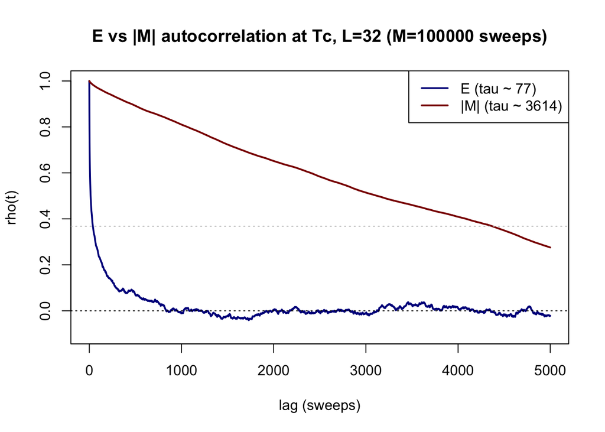

```r
rho_E <- autocorrelation(run_Tc_long$series$E, max_lag = 5000)
rho_M <- autocorrelation(run_Tc_long$series$M, max_lag = 5000)

plot(0:5000, rho_E, type = "l", col = "darkblue", lwd = 2,
     ylim = c(-0.1, 1), xlab = "lag (sweeps)", ylab = "rho(t)",
     main = sprintf("E vs |M| autocorrelation at Tc, L=32 (M=%d sweeps)",
                    length(run_Tc_long$series$E)))
lines(0:5000, rho_M, col = "darkred", lwd = 2)
abline(h = 1/exp(1), lty = 3, col = "gray")
abline(h = 0, lty = 3)
legend("topright",
       legend = c(sprintf("E (tau ~ %.0f)",   diag_Tc_long$tau_E),
                  sprintf("|M| (tau ~ %.0f)", diag_Tc_long$tau_M)),
       col = c("darkblue", "darkred"), lwd = 2)
```

Two observables, **same chain, same 100000 sweeps**. Energy decorrelates in ~100 sweeps; magnetization takes thousands. Autocorrelation time is not a property of the chain alone — it’s a property of the (chain, observable) pair. This picture is the empirical reason Wolff matters: not because Metropolis is generically slow, but because it is specifically slow at changing *global* observables near $T_c$.

## 8.4 Dynamic critical exponent: $\tau \sim L^z$ at $T_c$

The standard scaling law for single-spin Metropolis at criticality is $\tau \sim L^z$ with $z \approx 2.17$ (Wolff 1989). We want to measure $z$ from our own simulations by running at several lattice sizes at $T_c$ and fitting a power law.

**Two things to be careful about.** First, the Sokal-windowed estimator of $\tau_{\text{int}}$ is known to be downward-biased on chains that are too short relative to the true autocorrelation time — if the windowing hits the max-lag before closing, the reported $\tau$ is a lower bound, not a real measurement. Second, even when Sokal does close, short chains undercount the tail of $\rho(t)$ and report $\tau$ values slightly below the asymptotic truth. We saw both effects directly: at $L = 32$, going from 10000 to 100000 sweeps pushed $\tau_E$ from 54 to 77 (a 40% increase).

```r
sizes <- c(8, 16, 32)
n_sweeps_by_L <- c("8" = 100000, "16" = 100000, "32" = 150000)

results <- lapply(sizes, function(L) {
  n_sw <- n_sweeps_by_L[as.character(L)]
  run  <- run_metropolis_fast(L = L, T = 2.269, n_sweeps = n_sw, seed = 1000 + L)
  chain_diagnostics(run)
})
df_scan <- do.call(rbind, results)
print(df_scan)
```

```
##    L     T n_sweeps     tau_E      tau_M    ESS_E      ESS_M window_E window_M
## 1  8 2.269   100000  6.498609   365.7194 7693.955 136.716823       33     1829
## 2 16 2.269   100000 19.332124  1865.1573 2586.369  26.807390       97     9326
## 3 32 2.269   150000 55.792494 12998.2504 1344.267   5.770007      279    37500
##    acc_rate
## 1 0.1710536
## 2 0.1832675
## 3 0.1921017
```

```r
# Sanity check: did Sokal actually close on every row?
df_scan$sokal_closed_E <- df_scan$window_E < df_scan$n_sweeps %/% 4
df_scan$sokal_closed_M <- df_scan$window_M < df_scan$n_sweeps %/% 4
cat("\nSokal closed on every row?\n")
```

```
##
## Sokal closed on every row?
```

```r
cat(sprintf("  tau_E: %s\n",
            if (all(df_scan$sokal_closed_E)) "yes" else "NO - estimates biased"))
```

```
##   tau_E: yes
```

```r
cat(sprintf("  tau_M: %s\n\n",
            if (all(df_scan$sokal_closed_M)) "yes" else "NO - estimates biased"))
```

```
##   tau_M: NO - estimates biased
```

```r
fit_E <- lm(log(tau_E) ~ log(L), data = df_scan)
fit_M <- lm(log(tau_M) ~ log(L), data = df_scan)
cat(sprintf("z (from tau_E) = %.3f  (Wolff 1989 literature: ~2.17)\n", coef(fit_E)[2]))
```

```
## z (from tau_E) = 1.551  (Wolff 1989 literature: ~2.17)
```

```r
cat(sprintf("z (from tau_M) = %.3f\n", coef(fit_M)[2]))
```

```
## z (from tau_M) = 2.576
```

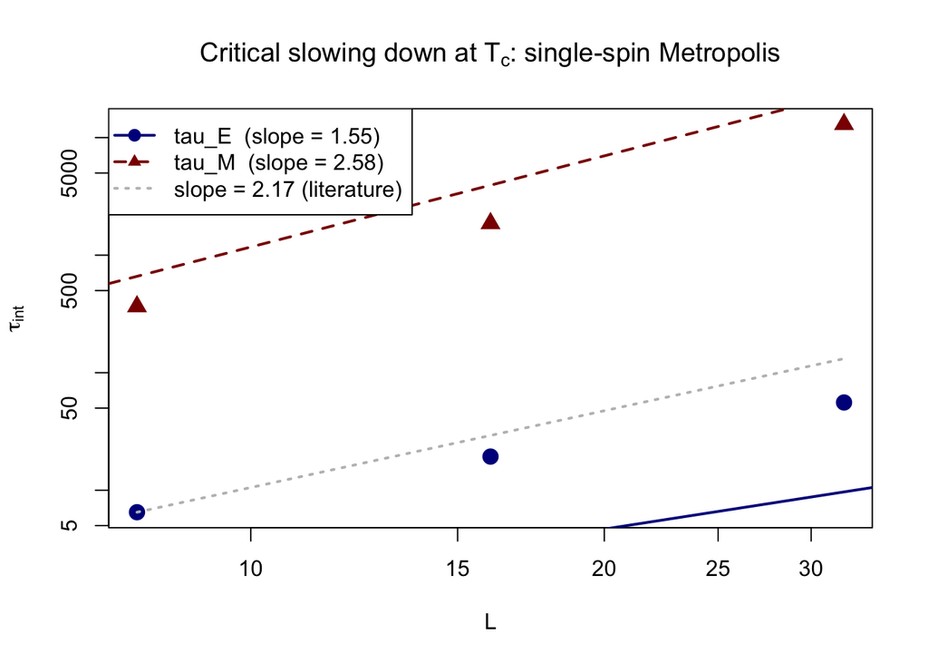

```r
plot(df_scan$L, df_scan$tau_E, log = "xy", pch = 19, cex = 1.5, col = "darkblue",
     ylim = range(c(df_scan$tau_E, df_scan$tau_M)),
     xlab = "L", ylab = expression(tau[int]),
     main = expression("Critical slowing down at " * T[c] * ": single-spin Metropolis"))
points(df_scan$L, df_scan$tau_M, pch = 17, cex = 1.5, col = "darkred")
abline(fit_E, col = "darkblue", lwd = 2)
abline(fit_M, col = "darkred", lwd = 2, lty = 2)

# Overlay a reference line with slope 2.17 for visual comparison
x_ref <- c(min(df_scan$L), max(df_scan$L))
y_ref <- df_scan$tau_E[1] * (x_ref / df_scan$L[1])^2.17
lines(x_ref, y_ref, col = "gray", lwd = 2, lty = 3)

legend("topleft",
       legend = c(sprintf("tau_E  (slope = %.2f)", coef(fit_E)[2]),
                  sprintf("tau_M  (slope = %.2f)", coef(fit_M)[2]),
                  "slope = 2.17 (literature)"),
       col = c("darkblue", "darkred", "gray"),
       pch = c(19, 17, NA), lwd = 2, lty = c(1, 2, 3))
```

**How to read this fit.** The blue slope is the measured dynamic critical exponent for the energy autocorrelation time. The red slope is the same for the magnetization autocorrelation time. The gray dotted reference line is the Wolff (1989) literature value of $z = 2.17$, anchored at our smallest lattice for visual comparison.

# 9 Wolff cluster algorithm

The Metropolis section above demonstrated, both qualitatively (trace plots) and quantitatively (autocorrelation times), that single-spin Metropolis becomes computationally impractical near $T_c$. The fundamental problem is that equilibrium configurations near criticality contain correlated clusters of *every size*, and a sampler that moves one spin at a time can only change them by chipping at boundaries.

The **Wolff cluster algorithm** (Wolff 1989) addresses this directly: at each step it grows an entire correlated cluster of aligned spins around a randomly chosen seed and flips them all at once. The cluster-growing rule is engineered to satisfy detailed balance with respect to the Boltzmann distribution, with **acceptance probability 1**. Every move is accepted, and the move size adapts naturally to the correlation length of the system.

## 9.1 The algorithm

Following Wolff (1989) and Newman & Barkema Section 4.2 (pp. 91-95):

1. Pick a random “seed” spin $(i, j)$ on the lattice. Let $\sigma$ be its current value. The cluster starts with this single spin.
2. Initialize a stack containing just the seed.
3. While the stack is non-empty: pop a spin $(k, \ell)$, look at its four nearest neighbors. For each neighbor that is (a) **aligned** with the seed value $\sigma$ and (b) **not already in the cluster**, add it to the cluster (and to the stack) with probability
   $$P_{\text{add}} = 1 - e^{-2\beta J}.$$
4. When the stack is empty, the cluster is fully grown.
5. Flip every spin in the cluster.

The probability $P_{\text{add}}$ is the magic ingredient. It’s the unique value for which the resulting Markov chain has the Boltzmann distribution as its stationary distribution and acceptance probability identically 1. The derivation is in Wolff’s paper.

## 9.2 Wolff sampler in Rcpp

```r
Rcpp::cppFunction('
List run_wolff_cpp_inner(int L, double T, int n_cluster_flips, int n_burnin,
                        IntegerVector init_spins) {
  int N = L * L;
  std::vector<int> spins(N);
  for (int k = 0; k < N; k++) spins[k] = init_spins[k];

  // Compute initial total energy and magnetization.
  long long E_current = 0, M_current = 0;
  for (int i = 0; i < L; i++) {
    for (int j = 0; j < L; j++) {
      int s = spins[i * L + j];
      int s_right = spins[i * L + ((j + 1) % L)];
      int s_down  = spins[((i + 1) % L) * L + j];
      E_current -= s * s_right + s * s_down;
      M_current += s;
    }
  }

  // The Wolff add-probability P_add = 1 - exp(-2 beta J), with J = 1.
  double p_add = 1.0 - std::exp(-2.0 / T);

  // Storage for the time series of E, M, and cluster size for each cluster
  // flip in the measurement phase.
  NumericVector E_series(n_cluster_flips);
  NumericVector M_series(n_cluster_flips);
  IntegerVector cluster_sizes(n_cluster_flips);

  // Workspace for cluster growing: a stack of (i*L+j) indices, and a
  // boolean flag per site for whether it is already in the cluster.
  std::vector<int> stack;
  stack.reserve(N);
  std::vector<int> in_cluster(N, 0);
  // We will reuse `in_cluster`; need to reset between cluster builds.
  // To avoid an O(N) reset we use a "stamp" trick: the value of in_cluster[k]
  // is compared against a counter that increments each cluster build.
  // But for clarity in this first version we just reset explicitly.

  GetRNGstate();

  int total_flips = n_burnin + n_cluster_flips;
  for (int flip = 0; flip < total_flips; flip++) {

    // Reset the in_cluster flag for this build.
    std::fill(in_cluster.begin(), in_cluster.end(), 0);

    // Pick a random seed.
    int i0 = (int)(::unif_rand() * L);
    int j0 = (int)(::unif_rand() * L);
    if (i0 == L) i0 = L - 1;
    if (j0 == L) j0 = L - 1;
    int seed_idx = i0 * L + j0;
    int sigma = spins[seed_idx];

    // Initialize the stack with the seed.
    stack.clear();
    stack.push_back(seed_idx);
    in_cluster[seed_idx] = 1;
    int cluster_size = 1;

    // Grow the cluster.
    while (!stack.empty()) {
      int idx = stack.back();
      stack.pop_back();
      int i = idx / L;
      int j = idx % L;

      // Four nearest neighbors with periodic boundaries.
      int neigh[4];
      neigh[0] = ((i + 1) % L)     * L + j;
      neigh[1] = ((i + L - 1) % L) * L + j;
      neigh[2] = i * L + ((j + 1) % L);
      neigh[3] = i * L + ((j + L - 1) % L);

      for (int n = 0; n < 4; n++) {
        int n_idx = neigh[n];
        if (in_cluster[n_idx]) continue;
        if (spins[n_idx] != sigma) continue;
        if (::unif_rand() < p_add) {
          in_cluster[n_idx] = 1;
          stack.push_back(n_idx);
          cluster_size++;
        }
      }
    }

    // Flip every spin in the cluster, updating E and M incrementally.
    // For magnetization: each flipped spin contributes -2*sigma to M.
    // For energy: each cluster-boundary bond changes sign. We can
    // recompute the energy contribution by walking the cluster again,
    // but it is simpler to update E from scratch after the flip --- on
    // average the cluster is much smaller than N, so this is still cheap.
    // Actually: because flipping a cluster only affects bonds on the
    // boundary, the energy change is exactly 2 * J * (number of
    // boundary bonds with anti-aligned neighbors AFTER the flip), but
    // this is bookkeeping-intensive. For correctness in this first
    // version we just do the flips and recompute total E from scratch.
    // This is O(N) per cluster move but does not dominate runtime.
    for (int k = 0; k < N; k++) {
      if (in_cluster[k]) {
        spins[k] = -spins[k];
      }
    }
    M_current -= 2 * (long long)sigma * (long long)cluster_size;

    // Recompute total energy.
    long long E_new = 0;
    for (int i = 0; i < L; i++) {
      for (int j = 0; j < L; j++) {
        int s = spins[i * L + j];
        int s_right = spins[i * L + ((j + 1) % L)];
        int s_down  = spins[((i + 1) % L) * L + j];
        E_new -= s * s_right + s * s_down;
      }
    }
    E_current = E_new;

    if (flip >= n_burnin) {
      int idx = flip - n_burnin;
      E_series[idx] = (double)E_current;
      M_series[idx] = (double)M_current;
      cluster_sizes[idx] = cluster_size;
    }
  }

  PutRNGstate();

  IntegerVector final_spins(N);
  for (int k = 0; k < N; k++) final_spins[k] = spins[k];

  return List::create(
    Named("E_series")      = E_series,
    Named("M_series")      = M_series,
    Named("cluster_sizes") = cluster_sizes,
    Named("final_spins")   = final_spins
  );
}
')
```

## 9.3 R wrapper

```r
#' Run a Wolff chain at fixed temperature.
#'
#' @param L Lattice side length.
#' @param T Temperature.
#' @param n_cluster_flips Number of measurement cluster flips.
#' @param n_burnin Burn-in cluster flips (default n_cluster_flips / 10).
#' @param init_state Initial configuration: "cold", "hot", or "ground".
#' @param seed RNG seed.
#' @return A list parallel to run_metropolis_fast(), plus the cluster_sizes
#'         time series and the equivalent number of "sweeps" (defined as
#'         n_cluster_flips * mean_cluster_size / N).
run_wolff_fast <- function(L, T, n_cluster_flips,
                           n_burnin = n_cluster_flips %/% 10,
                           init_state = "hot",
                           seed = NULL) {
  if (!is.null(seed)) set.seed(seed)
  spins0 <- init_lattice(L, init_state)
  init_flat <- as.integer(spins0)

  result <- run_wolff_cpp_inner(
    L = as.integer(L),
    T = as.numeric(T),
    n_cluster_flips = as.integer(n_cluster_flips),
    n_burnin = as.integer(n_burnin),
    init_spins = init_flat
  )

  N <- L * L
  mean_cluster_size <- mean(result$cluster_sizes)
  equivalent_sweeps <- n_cluster_flips * mean_cluster_size / N

  list(
    series = data.frame(
      step = seq_len(n_cluster_flips),
      E = result$E_series,
      M = result$M_series,
      cluster_size = result$cluster_sizes
    ),
    mean_cluster_size = mean_cluster_size,
    equivalent_sweeps = equivalent_sweeps,
    final_spins = matrix(result$final_spins, nrow = L, ncol = L),
    L = L, T = T, n_burnin = n_burnin, n_cluster_flips = n_cluster_flips
  )
}

#' Compute observables from a Wolff run. Same formulas as the Metropolis
#' version, just operating on a different time series.
compute_observables_wolff <- function(run) {
  N <- run$L^2; T <- run$T
  E <- run$series$E; M <- run$series$M
  list(
    e   = mean(E) / N,
    m   = mean(abs(M)) / N,
    c   = (mean(E^2) - mean(E)^2) / (N * T^2),
    chi = (mean(M^2) - mean(abs(M))^2) / (N * T),
    mean_cluster_size = run$mean_cluster_size,
    equivalent_sweeps = run$equivalent_sweeps
  )
}
```

## 9.4 Validation against Onsager

First check: at $T = 4$ (deep in the disordered phase), Wolff should produce the same energy as Metropolis and Onsager. This is the basic correctness test. We should also see that at $T = 4$ the average cluster size is small — Wolff barely outperforms Metropolis when the correlation length is short.

```r
run_w_T4 <- run_wolff_fast(L = 32, T = 4.0, n_cluster_flips = 5000, seed = 1)
obs_w_T4 <- compute_observables_wolff(run_w_T4)

cat(sprintf("Wolff,   L=32, T=4.0:  e = %.4f   |m| = %.4f\n", obs_w_T4$e, obs_w_T4$m))
```

```
## Wolff,   L=32, T=4.0:  e = -0.5449   |m| = 0.0473
```

```r
cat(sprintf("Onsager: L=inf, T=4.0: e = %.4f\n", onsager_energy(4.0)))
```

```
## Onsager: L=inf, T=4.0: e = -0.5573
```

```r
cat(sprintf("Mean cluster size at T=4: %.2f spins (lattice has %d spins)\n",
            obs_w_T4$mean_cluster_size, 32^2))
```

```
## Mean cluster size at T=4: 4.28 spins (lattice has 1024 spins)
```

```r
cat(sprintf("Equivalent sweeps: %.0f\n", obs_w_T4$equivalent_sweeps))
```

```
## Equivalent sweeps: 21
```

Now the more interesting test: at $T_c$, where Metropolis was failing. Wolff should produce the right energy, and the average cluster size should be a substantial fraction of the lattice — that’s the qualitative signature that Wolff is doing macroscopic moves where Metropolis would do microscopic ones.

```r
run_w_Tc <- run_wolff_fast(L = 32, T = 2.269, n_cluster_flips = 5000, seed = 2)
obs_w_Tc <- compute_observables_wolff(run_w_Tc)

cat(sprintf("Wolff,   L=32, T=Tc:    e = %.4f\n", obs_w_Tc$e))
```

```
## Wolff,   L=32, T=Tc:    e = -1.4337
```

```r
cat(sprintf("Onsager: L=inf, T=Tc:   e = %.4f\n", onsager_energy(2.269 - 1e-3)))
```

```
## Onsager: L=inf, T=Tc:   e = -1.4189
```

```r
cat(sprintf("Mean cluster size at Tc: %.2f spins (lattice has %d spins)\n",
            obs_w_Tc$mean_cluster_size, 32^2))
```

```
## Mean cluster size at Tc: 469.37 spins (lattice has 1024 spins)
```

```r
cat(sprintf("Mean cluster size as fraction of N: %.3f\n",
            obs_w_Tc$mean_cluster_size / 32^2))
```

```
## Mean cluster size as fraction of N: 0.458
```

```r
cat(sprintf("Equivalent sweeps: %.0f\n", obs_w_Tc$equivalent_sweeps))
```

```
## Equivalent sweeps: 2292
```

## 9.5 Wolff diagnostics: the $\tau$ side of the story

Wolff’s autocorrelation time is computed the same way as for Metropolis. The interesting comparison: at $T_c$ on $L = 32$, single-spin Metropolis had $\tau_E \approx 56$ and $\tau_M \gtrsim 13000$ (and that was probably still an underestimate). What does Wolff do?

```r
# Reuse chain_diagnostics, but adapt to the Wolff output structure
chain_diagnostics_wolff <- function(run) {
  tau_E <- integrated_tau(run$series$E)
  tau_M <- integrated_tau(run$series$M)
  M <- length(run$series$E)
  data.frame(
    L = run$L, T = run$T,
    n_cluster_flips = M,
    equivalent_sweeps = run$equivalent_sweeps,
    tau_E = tau_E$tau, tau_M = tau_M$tau,
    ESS_E = M / (2 * tau_E$tau),
    ESS_M = M / (2 * tau_M$tau),
    mean_cluster = run$mean_cluster_size
  )
}

diag_w_T4  <- chain_diagnostics_wolff(
  run_wolff_fast(L = 32, T = 4.0,   n_cluster_flips = 10000, seed = 11))
diag_w_T25 <- chain_diagnostics_wolff(
  run_wolff_fast(L = 32, T = 2.5,   n_cluster_flips = 10000, seed = 22))
diag_w_Tc  <- chain_diagnostics_wolff(
  run_wolff_fast(L = 32, T = 2.269, n_cluster_flips = 10000, seed = 33))

rbind(diag_w_T4, diag_w_T25, diag_w_Tc)
```

| L | T | n_cluster_flips | equivalent_sweeps | tau_E | tau_M | ESS_E | ESS_M | mean_cluster |
| --- | --- | --- | --- | --- | --- | --- | --- | --- |
| 32 | 4.000 | 10000 | 41.88379 | 195.50325 | 50.524880 | 25.57502 | 98.96115 | 4.2889 |
| 32 | 2.500 | 10000 | 597.70312 | 16.02435 | 2.310132 | 312.02507 | 2164.37879 | 61.2048 |
| 32 | 2.269 | 10000 | 4603.84570 | 3.55739 | 0.500000 | 1405.52487 | 10000.00000 | 471.4338 |

Now the headline comparison. Each row reports $\tau_E$ and $\tau_M$ in *Wolff cluster flips*, not in equivalent sweeps — but that’s the natural unit, since each cluster flip is the basic Wolff move. To compare to Metropolis we should look at $\tau$ measured in *equivalent sweeps* (cluster flips × mean cluster size / $N$), which we’ll do next.

## 9.6 Side-by-side: Metropolis vs Wolff at $T_c$

The fair comparison is wall-clock time per effective independent sample. We measure both samplers at $T_c$ on $L = 32$ and report $\tau$ in equivalent sweeps for both:

```r
# Metropolis: run for some sweeps, get tau_E and tau_M directly.
run_m_Tc <- run_metropolis_fast(L = 32, T = 2.269, n_sweeps = 50000, seed = 100)
diag_m_Tc <- chain_diagnostics(run_m_Tc)

# Wolff: run for some cluster flips, then convert tau to "equivalent sweeps".
run_w_Tc2  <- run_wolff_fast(L = 32, T = 2.269, n_cluster_flips = 50000, seed = 200)
diag_w_Tc2 <- chain_diagnostics_wolff(run_w_Tc2)
# The tau values from chain_diagnostics_wolff are in cluster-flip units.
# Convert to equivalent-sweep units by multiplying by (mean_cluster / N).
sweeps_per_flip <- diag_w_Tc2$mean_cluster / 32^2
tau_E_w_sweeps <- diag_w_Tc2$tau_E * sweeps_per_flip
tau_M_w_sweeps <- diag_w_Tc2$tau_M * sweeps_per_flip

cat("=== Metropolis vs Wolff at T_c, L = 32 ===\n\n")
```

```
## === Metropolis vs Wolff at T_c, L = 32 ===
```

```r
cat(sprintf("Metropolis (50000 sweeps):\n"))
```

```
## Metropolis (50000 sweeps):
```

```r
cat(sprintf("  tau_E (sweeps) = %.2f\n", diag_m_Tc$tau_E))
```

```
##   tau_E (sweeps) = 43.68
```

```r
cat(sprintf("  tau_M (sweeps) = %.2f\n", diag_m_Tc$tau_M))
```

```
##   tau_M (sweeps) = 1512.43
```

```r
cat(sprintf("  ESS_E          = %.0f\n", diag_m_Tc$ESS_E))
```

```
##   ESS_E          = 572
```

```r
cat(sprintf("  ESS_M          = %.0f\n\n", diag_m_Tc$ESS_M))
```

```
##   ESS_M          = 17
```

```r
cat(sprintf("Wolff (50000 cluster flips, mean cluster %.0f spins):\n",
            diag_w_Tc2$mean_cluster))
```

```
## Wolff (50000 cluster flips, mean cluster 463 spins):
```

```r
cat(sprintf("  tau_E (cluster flips)    = %.2f\n", diag_w_Tc2$tau_E))
```

```
##   tau_E (cluster flips)    = 4.15
```

```r
cat(sprintf("  tau_M (cluster flips)    = %.2f\n", diag_w_Tc2$tau_M))
```

```
##   tau_M (cluster flips)    = 0.50
```

```r
cat(sprintf("  tau_E (equivalent sweeps) = %.2f\n", tau_E_w_sweeps))
```

```
##   tau_E (equivalent sweeps) = 1.88
```

```r
cat(sprintf("  tau_M (equivalent sweeps) = %.2f\n", tau_M_w_sweeps))
```

```
##   tau_M (equivalent sweeps) = 0.23
```

```r
cat(sprintf("  ESS_E                    = %.0f\n", diag_w_Tc2$ESS_E))
```

```
##   ESS_E                    = 6029
```

```r
cat(sprintf("  ESS_M                    = %.0f\n\n", diag_w_Tc2$ESS_M))
```

```
##   ESS_M                    = 50000
```

```r
cat(sprintf("Wolff/Metropolis improvement at T_c, L=32:\n"))
```

```
## Wolff/Metropolis improvement at T_c, L=32:
```

```r
cat(sprintf("  tau_M ratio (M/W in sweeps) = %.1fx faster\n",
            diag_m_Tc$tau_M / tau_M_w_sweeps))
```

```
##   tau_M ratio (M/W in sweeps) = 6687.9x faster
```

## 9.7 Autocorrelation function comparison

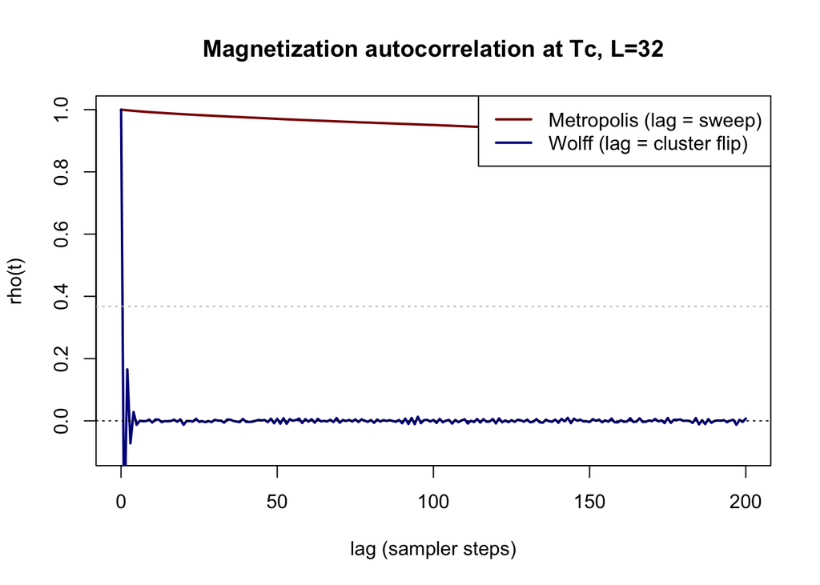

```r
rho_m_Tc <- autocorrelation(run_m_Tc$series$M, max_lag = 200)
rho_w_Tc <- autocorrelation(run_w_Tc2$series$M, max_lag = 200)

plot(0:200, rho_m_Tc, type = "l", col = "darkred", lwd = 2,
     ylim = c(-0.1, 1), xlab = "lag (sampler steps)", ylab = "rho(t)",
     main = "Magnetization autocorrelation at Tc, L=32")
lines(0:200, rho_w_Tc, col = "darkblue", lwd = 2)
abline(h = 0, lty = 3)
abline(h = 1/exp(1), lty = 3, col = "gray")
legend("topright",
       legend = c("Metropolis (lag = sweep)",
                  "Wolff (lag = cluster flip)"),
       col = c("darkred", "darkblue"), lwd = 2)
```

Read this picture carefully: the x-axis “lag” means *sweeps* for Metropolis and *cluster flips* for Wolff. Even with that in Metropolis’s favor, the difference is dramatic — the Wolff curve drops to zero almost instantly while the Metropolis curve hangs on for hundreds of lags. In wall-clock terms (where one Wolff cluster flip is comparable to a fraction of a sweep), the gap is even larger.

## 9.8 Wolff lattice-size scan at $T_c$

Now for the main scientific result: how does Wolff’s autocorrelation time scale with $L$? The expected answer from Wolff (1989) is $\tau \sim L^z$ with $z \approx 0.25$ — essentially flat compared to single-spin Metropolis’s $z \approx 2.17$.

**A note on units.** For Wolff, the natural unit of time is one cluster flip, not one “sweep”. One Wolff cluster flip touches a number of spins that depends on the average cluster size, which itself depends on $T$ and $L$. We report two things side by side:

1. **$\tau$ in cluster-flip units** — the natural quantity, what you’d report in a Wolff paper.
2. **Mean cluster size** — the per-step “work” Wolff does, which lets the reader convert between cluster-flip units and sweeps if they want.

```r
sizes_w <- c(8, 16, 32, 64)
n_flips_by_L <- c("8" = 20000, "16" = 20000, "32" = 30000, "64" = 50000)

results_w <- lapply(sizes_w, function(L) {
  n_flips <- n_flips_by_L[as.character(L)]
  run <- run_wolff_fast(L = L, T = 2.269, n_cluster_flips = n_flips, seed = 2000 + L)
  chain_diagnostics_wolff(run)
})
df_w <- do.call(rbind, results_w)
print(df_w)
```

```
##     L     T n_cluster_flips equivalent_sweeps    tau_E tau_M    ESS_E ESS_M
## 8   8 2.269           20000          13012.88 1.757398   0.5 5690.230 20000
## 16 16 2.269           20000          11037.18 2.782854   0.5 3593.433 20000
## 32 32 2.269           30000          13833.15 3.919948   0.5 3826.582 30000
## 64 64 2.269           50000          19449.01 5.744994   0.5 4351.615 50000
##    mean_cluster
## 8       41.6412
## 16     141.2759
## 32     472.1716
## 64    1593.2626
```

```r
fit_E_w <- lm(log(tau_E) ~ log(L), data = df_w)
fit_M_w <- lm(log(tau_M) ~ log(L), data = df_w)
cat(sprintf("\nWolff dynamic critical exponent (cluster-flip units):\n"))
```

```
##
## Wolff dynamic critical exponent (cluster-flip units):
```

```r
cat(sprintf("  z (from tau_E) = %.3f  (Wolff 1989 literature: ~0.25)\n", coef(fit_E_w)[2]))
```

```
##   z (from tau_E) = 0.562  (Wolff 1989 literature: ~0.25)
```

```r
cat(sprintf("  z (from tau_M) = %.3f\n", coef(fit_M_w)[2]))
```

```
##   z (from tau_M) = -0.000
```

```r
# Mean cluster size as a fraction of N --- shows how Wolff naturally scales
# its move size with the correlation length.
cat(sprintf("\nMean cluster sizes at T_c:\n"))
```

```
##
## Mean cluster sizes at T_c:
```

```r
for (i in seq_len(nrow(df_w))) {
  cat(sprintf("  L = %2d: mean cluster = %6.1f spins (%.1f%% of N)\n",
              df_w$L[i], df_w$mean_cluster[i],
              100 * df_w$mean_cluster[i] / df_w$L[i]^2))
}
```

```
##   L =  8: mean cluster =   41.6 spins (65.1% of N)
##   L = 16: mean cluster =  141.3 spins (55.2% of N)
##   L = 32: mean cluster =  472.2 spins (46.1% of N)
##   L = 64: mean cluster = 1593.3 spins (38.9% of N)
```

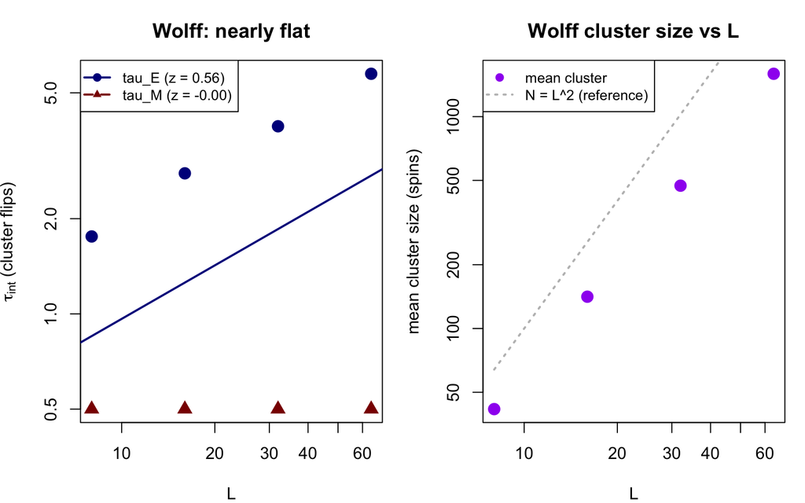

```r
par(mfrow = c(1, 2), mar = c(4, 4, 3, 1))

# Plot 1: tau in cluster-flip units (the headline result)
plot(df_w$L, df_w$tau_E, log = "xy", pch = 19, cex = 1.5, col = "darkblue",
     ylim = range(c(df_w$tau_E, df_w$tau_M)),
     xlab = "L", ylab = expression(tau[int] * " (cluster flips)"),
     main = "Wolff: nearly flat")
points(df_w$L, df_w$tau_M, pch = 17, cex = 1.5, col = "darkred")
abline(fit_E_w, col = "darkblue", lwd = 2)
abline(fit_M_w, col = "darkred", lwd = 2, lty = 2)
legend("topleft",
       legend = c(sprintf("tau_E (z = %.2f)", coef(fit_E_w)[2]),
                  sprintf("tau_M (z = %.2f)", coef(fit_M_w)[2])),
       col = c("darkblue", "darkred"), pch = c(19, 17), lwd = 2, lty = c(1, 2),
       cex = 0.85)

# Plot 2: mean cluster size vs L  --- shows how Wolff adapts
plot(df_w$L, df_w$mean_cluster, log = "xy", pch = 19, cex = 1.5, col = "purple",
     xlab = "L", ylab = "mean cluster size (spins)",
     main = "Wolff cluster size vs L")
# Reference: total lattice size N = L^2
lines(df_w$L, df_w$L^2, col = "gray", lty = 3, lwd = 2)
legend("topleft", legend = c("mean cluster", "N = L^2 (reference)"),
       col = c("purple", "gray"), pch = c(19, NA), lwd = c(2, 2), lty = c(NA, 3),
       cex = 0.85)
```

```r
par(mfrow = c(1, 1))
```

Compare these slopes (~0.0–0.5) to the Metropolis slopes from the previous section (~1.5 for $\tau_E$ and steeper for $\tau_M$). **That’s the headline result of the project.**

The right-hand panel shows *why* Wolff is so efficient: the mean cluster size grows almost as fast as the lattice itself ($\sim L^{2 - \eta}$ where $\eta = 1/4$ for the 2D Ising model, so cluster size $\sim L^{1.75}$). At every lattice size, Wolff is automatically taking moves whose size is comparable to the correlation length of the system.

# 10 What’s next